# Proyecto 3 - CDG

2022-07-03

Nombres: Francisco Reyes Valeria Pichott Moussa Saker

Área de estudio: Para este trabajo se decidió usar la comuna de Las Condes de la región metropolitana, seleccionando tanto casas como departamentos, y también, seleccionamos únicamente las variables que consideramos que podrían llegar a tener algún impacto en el precio de las viviendas, tales como; El avalúo fiscal, el año de inscripción en el CBR, el año de construcción de la vivienda, cantidad a pagar en las contribuciones, los metros cuadrados de superficie de terreno como también los de superficie construida, cuántos estacionamientos tiene, índice de moran local para casas y departamentos, las distintas cantidades de habitantes y sus proporciones. También se consideraron muchas variables con respecto a las manzanas de las viviendas, como; el número de manzana del SII, el UF/m2 promedio para casas y departamentos, población flotante, el índice de vegetación, el área, la densidad poblacional. Por otro lado se usaron aquellas variables en relación a las distancias y establecimientos, tales como; el tiempo en transporte privado a SC más cercano, a un SC CBD, al Golf, a Nueva las Condes, a Providencia. También es importante saber si se tiene un subcentro, metro, colegio o centro educacional, jardín, áreas verdes, comercio, centro de salud, distintos servicios y barrios de oficina a menos de 15, 10 y 5 minutos de distancia. Por último, y el más importante, el valor de la vivienda en UF. Con esta variable es con la que se va a comparar los resultados y concluir sobre los precios de la viviendas. Variables como la dirección de la vivienda, la fecha de inscripción en el CBR, nombre de la calle, código de la comuna, etc. no fueron consideradas en el estudio porque se consideran intrascendentes en la variabilidad del precio.

Hipótesis: Analizar qué factores afectan el precio de las viviendas de forma general, utilizando el método de clustering para realizar agrupaciones por similitudes, y así encontrar parámetros que afecten el precio de las viviendas ubicadas en la comuna de Las Condes. Las variables relacionadas a características de la vivienda, como lo pueden ser el año de construcción, el número de estacionamiento, los m2 cuadrados de superficie del terreno, entre otras, y el tiempo de traslado a los diferentes subcentros en las Condes, son las que mejor clasifican las agrupaciones de las viviendas y las que mayor impacto tienen en los precios de estas.

```r
# Importamos las librerias
pacman::p_load(rgdal, rgeos, stars, spatstat, spdep, sf, raster, tidyverse,
               spatialreg, tidyverse, vapour, gstat, MASS, spdep, tmap, mapview,foreign,factoextra,dplyr,e1071,
               caret,paran,fpc)
```

```r
#Cargamos los datos
data = read.dbf('RM_SII_CBR2.dbf')
geom = st_read('RM_SII_CBR2.shp')
```

# Limpieza de datos

Procesamiento y limpieza de datos: Para el procesamiento y limpieza de datos lo primero que se realizó fue seleccionar las variables de interés del archivo de base de datos dBase (.dbf) y del archivo de ubicación geométrica (.shp). Luego se reemplazaron las variables nulas de cada columna por el promedio de los valores de dichas columnas y así tener un mejor procesamiento de la data, sin datos que nos ensucien el análisis. Por otro lado, se realizó un PCA (Análisis de componentes principales) para determinar cuáles son las variables que más información aportan, ya que, como existen muchas variables, este método estadístico permite simplificar la complejidad de espacios muestrales con muchas dimensiones a la vez que conserva su información. Entregando un número de componentes que logran “resumir” la información de la data. De este estudio uno logra obtener cierta cantidad de componentes pero que a continuación se calcula los eigenvalues, los cuales nos ayudan a retener las componentes que más importancia tienen, obteniendo 13 componentes importantes de dicho proceso. Posteriormente, se ve cuales son las variables que tienen más peso tienen, en términos de información, para cada componentes. Así fue como para el primer componente se tiene que la variable TPR_ElGolf es la que más información aporta, para el segundo componente es la variable Depto_UFPr. para el tercero es EDUCACION, para el cuarto es CONTRIBUCION, para el quinto es C2_12, etc.

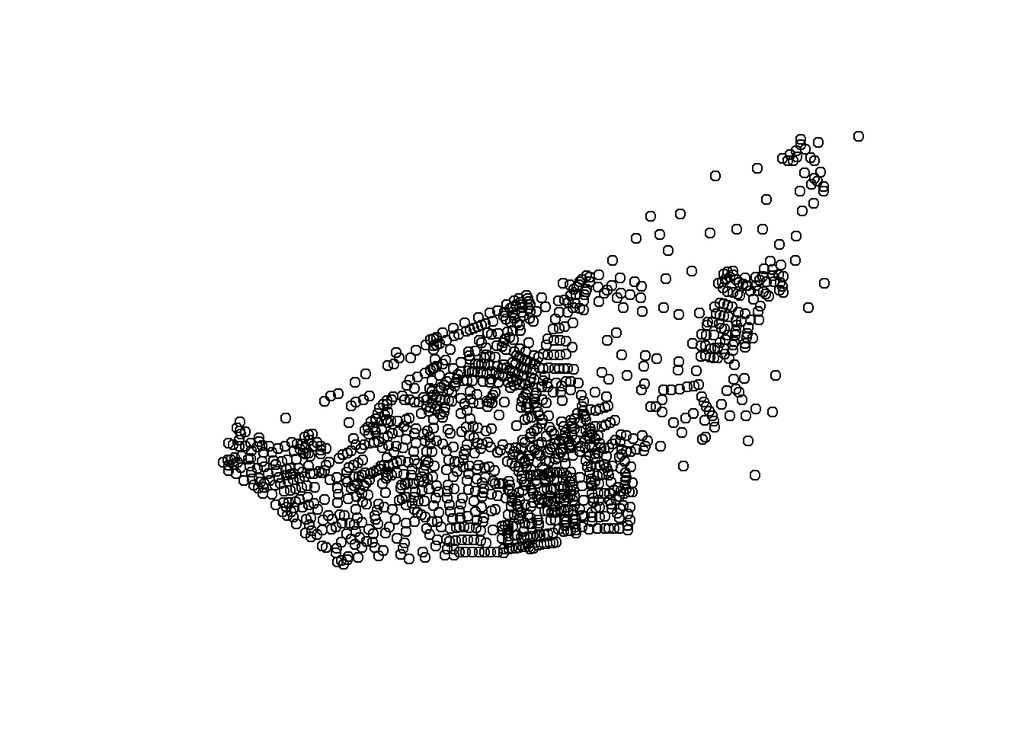

```r
#--------------------Limpieza de datos----------------
#Seleccionamos la comuna de las condes
datos_lascondes = data %>% dplyr::filter(COMUNA == 'LAS CONDES')
geom_las_condes = geom %>% dplyr::filter(COMUNA == 'LAS CONDES')

#Seleccionamos las columnas para nuestro análisis
data_s = datos_lascondes %>% dplyr::select(AVALUO, ANO, ANO_CONSTR, MANZ,CONTRIBUCI,SUP_TERR,ANO_CONSTR,SUP_CONSTR,UF_TRANS,ESTACIONAM,SC_TPRIV,
                                TPR_CBD,TPR_ElGolf,TPR_NvaLCo,TPR_Provi,Casas_UFPr,Depto_UFPr,IMORANCASA,IMORANDPTO,ABC1_12,
                                C2_12,C3_12,D_12,E_12,ABC1_12P,C2_12P,C3_12P,D_12P,E_12P,POB_FLOT,Por_veg_pr,HA_MZ,DEN_MZ,SC_15MIN,
                                Ten_Metro,Ten_MetroC,COLE_5MIN,COLE_10MIN,COLE_10MIN,JARDIN_5M,JARDIN_10M,JARDIN_15M,AV_15_MIN,
                                COMERCIO,EDUCACION,SALUD,SERVICIOS,OFICINA,IMORANCASA,IMORANDPTO)

geom_s = geom_las_condes %>% dplyr::select(AVALUO, ANO, ANO_CONSTR, MANZ,CONTRIBUCI,SUP_TERR,ANO_CONSTR,SUP_CONSTR,UF_TRANS,ESTACIONAM,SC_TPRIV,
                                TPR_CBD,TPR_ElGolf,TPR_NvaLCo,TPR_Provi,Casas_UFPr,Depto_UFPr,IMORANCASA,IMORANDPTO,ABC1_12,
                                C2_12,C3_12,D_12,E_12,ABC1_12P,C2_12P,C3_12P,D_12P,E_12P,POB_FLOT,Por_veg_pr,HA_MZ,DEN_MZ,SC_15MIN,
                                Ten_Metro,Ten_MetroC,COLE_5MIN,COLE_10MIN,COLE_10MIN,JARDIN_5M,JARDIN_10M,JARDIN_15M,AV_15_MIN,
                                COMERCIO,EDUCACION,SALUD,SERVICIOS,OFICINA,IMORANCASA,IMORANDPTO,geometry)


#Reemplazamos los na por la media de su columna
NA2mean = function(x) replace(x, is.na(x),mean(x, na.rm = TRUE))
datos_sin_na = replace(data_s, TRUE, lapply(data_s, NA2mean))
geom_sin_na = replace(geom_s, TRUE, lapply(geom_s, NA2mean))
#Graficamos los datos de las condes
plot(st_geometry(geom_sin_na))
```

```r
#----------------Hacemos un PCA para determinar cuales son las variables que más información aportan----------------
pca = prcomp(datos_sin_na,scale=T)
summary(pca)
```

```
## Importance of components:
##                           PC1    PC2     PC3     PC4     PC5     PC6     PC7
## Standard deviation     3.2776 2.2520 1.75653 1.67112 1.47472 1.38275 1.33192
## Proportion of Variance 0.2335 0.1103 0.06707 0.06071 0.04728 0.04157 0.03857
## Cumulative Proportion  0.2335 0.3438 0.41086 0.47157 0.51885 0.56042 0.59898
##                            PC8     PC9    PC10    PC11    PC12   PC13    PC14
## Standard deviation     1.24024 1.18026 1.05826 1.05247 1.02126 1.0013 0.99643
## Proportion of Variance 0.03344 0.03028 0.02435 0.02408 0.02267 0.0218 0.02158
## Cumulative Proportion  0.63242 0.66271 0.68705 0.71113 0.73380 0.7556 0.77718
##                           PC15    PC16    PC17    PC18    PC19    PC20    PC21
## Standard deviation     0.97209 0.94637 0.92178 0.85540 0.80172 0.75784 0.75480
## Proportion of Variance 0.02054 0.01947 0.01847 0.01591 0.01397 0.01249 0.01239
## Cumulative Proportion  0.79773 0.81720 0.83567 0.85157 0.86555 0.87803 0.89042
##                           PC22    PC23    PC24    PC25    PC26   PC27   PC28
## Standard deviation     0.74273 0.70538 0.67368 0.64606 0.62047 0.5753 0.5635
## Proportion of Variance 0.01199 0.01082 0.00987 0.00907 0.00837 0.0072 0.0069
## Cumulative Proportion  0.90241 0.91323 0.92309 0.93217 0.94054 0.9477 0.9546
##                           PC29    PC30    PC31    PC32    PC33    PC34    PC35
## Standard deviation     0.52037 0.50440 0.48724 0.48560 0.46190 0.42866 0.39902
## Proportion of Variance 0.00589 0.00553 0.00516 0.00513 0.00464 0.00399 0.00346
## Cumulative Proportion  0.96052 0.96605 0.97121 0.97634 0.98098 0.98497 0.98843
##                           PC36    PC37    PC38    PC39   PC40    PC41    PC42
## Standard deviation     0.38461 0.36426 0.28722 0.26050 0.2252 0.13440 0.11458
## Proportion of Variance 0.00322 0.00288 0.00179 0.00148 0.0011 0.00039 0.00029
## Cumulative Proportion  0.99165 0.99453 0.99633 0.99780 0.9989 0.99930 0.99958
##                           PC43    PC44      PC45      PC46
## Standard deviation     0.10463 0.09069 1.121e-12 1.456e-15
## Proportion of Variance 0.00024 0.00018 0.000e+00 0.000e+00
## Cumulative Proportion  0.99982 1.00000 1.000e+00 1.000e+00
```

```r
#Calculamos y graficamos la varianza de cada componente
prop_varianza = pca$sdev^2 / sum(pca$sdev^2)
prop_varianza
```

```
##  [1] 2.335367e-01 1.102539e-01 6.707398e-02 6.070989e-02 4.727810e-02
##  [6] 4.156505e-02 3.856570e-02 3.343921e-02 3.028276e-02 2.434602e-02
## [11] 2.408015e-02 2.267317e-02 2.179512e-02 2.158411e-02 2.054260e-02
## [16] 1.947002e-02 1.847130e-02 1.590680e-02 1.397288e-02 1.248528e-02
## [21] 1.238527e-02 1.199228e-02 1.081643e-02 9.866262e-03 9.073816e-03
## [26] 8.369329e-03 7.195155e-03 6.903293e-03 5.886625e-03 5.530894e-03
## [31] 5.160925e-03 5.126250e-03 4.638091e-03 3.994520e-03 3.461307e-03
## [36] 3.215751e-03 2.884521e-03 1.793434e-03 1.475236e-03 1.102971e-03
## [41] 3.926959e-04 2.853807e-04 2.379968e-04 1.788034e-04 2.730691e-26
## [46] 4.605700e-32
```

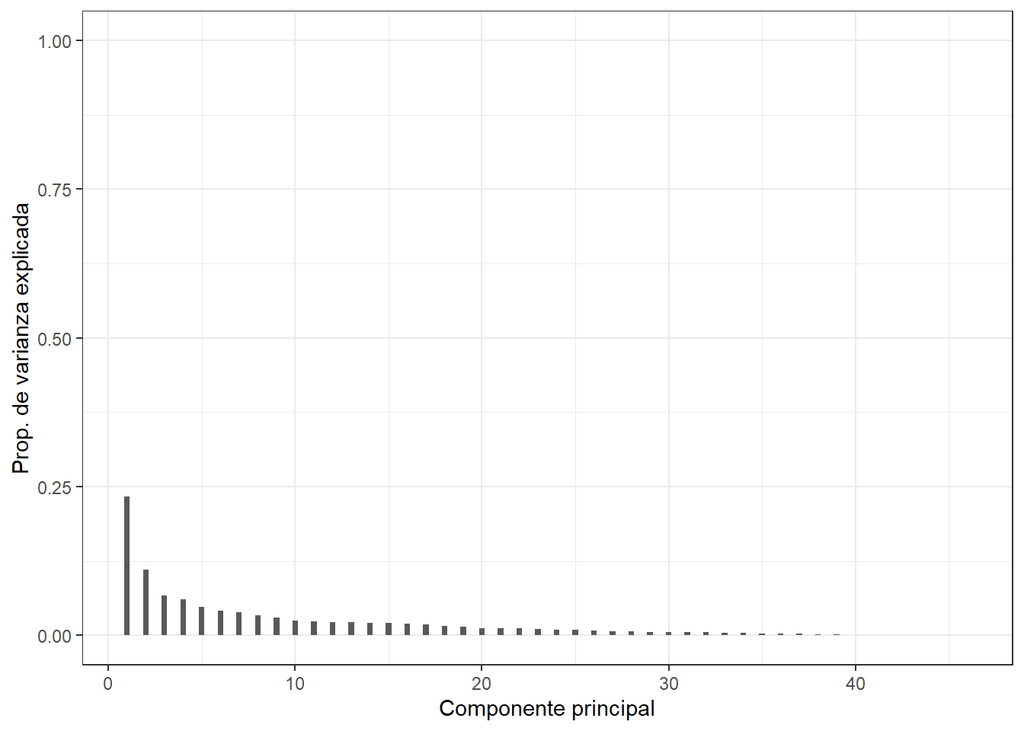

```r
ggplot(data = data.frame(prop_varianza, pc = 1:46),
       aes(x = pc, y = prop_varianza)) +
  geom_col(width = 0.3) +
  scale_y_continuous(limits = c(0,1)) +
  theme_bw() +
  labs(x = "Componente principal",
       y = "Prop. de varianza explicada")
```

```r
#Calculamos y graficamos la varianza acumulada
prop_varianza_acum = cumsum(prop_varianza)
prop_varianza_acum
```

```
##  [1] 0.2335367 0.3437906 0.4108646 0.4715745 0.5188526 0.5604176 0.5989833
##  [8] 0.6324226 0.6627053 0.6870513 0.7111315 0.7338047 0.7555998 0.7771839
## [15] 0.7977265 0.8171965 0.8356678 0.8515746 0.8655475 0.8780328 0.8904180
## [22] 0.9024103 0.9132267 0.9230930 0.9321668 0.9405361 0.9477313 0.9546346
## [29] 0.9605212 0.9660521 0.9712130 0.9763393 0.9809774 0.9849719 0.9884332
## [36] 0.9916490 0.9945335 0.9963269 0.9978022 0.9989051 0.9992978 0.9995832
## [43] 0.9998212 1.0000000 1.0000000 1.0000000
```

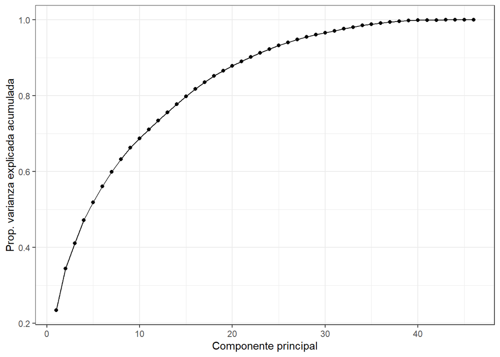

```r
ggplot(data = data.frame(prop_varianza_acum, pc = 1:46),
       aes(x = pc, y = prop_varianza_acum, group = 1)) +
  geom_point() +
  geom_line() +
  theme_bw() +
  labs(x = "Componente principal",
       y = "Prop. varianza explicada acumulada")
```

```r
#Calculamos los eigenvalues, que nos ayudan a retener las componentes más importantes bajo el criterio de
# eigenvalue >= 1
eig.val = get_eigenvalue(pca)
eig.val #de esta tabla concluimos con que las principales 13 componentes sirven
```

```
##          eigenvalue variance.percent cumulative.variance.percent
## Dim.1  1.074269e+01     2.335367e+01                    23.35367
## Dim.2  5.071680e+00     1.102539e+01                    34.37906
## Dim.3  3.085403e+00     6.707398e+00                    41.08646
## Dim.4  2.792655e+00     6.070989e+00                    47.15745
## Dim.5  2.174793e+00     4.727810e+00                    51.88526
## Dim.6  1.911992e+00     4.156505e+00                    56.04176
## Dim.7  1.774022e+00     3.856570e+00                    59.89833
## Dim.8  1.538204e+00     3.343921e+00                    63.24226
## Dim.9  1.393007e+00     3.028276e+00                    66.27053
## Dim.10 1.119917e+00     2.434602e+00                    68.70513
## Dim.11 1.107687e+00     2.408015e+00                    71.11315
## Dim.12 1.042966e+00     2.267317e+00                    73.38047
## Dim.13 1.002575e+00     2.179512e+00                    75.55998
## Dim.14 9.928693e-01     2.158411e+00                    77.71839
## Dim.15 9.449598e-01     2.054260e+00                    79.77265
## Dim.16 8.956210e-01     1.947002e+00                    81.71965
## Dim.17 8.496798e-01     1.847130e+00                    83.56678
## Dim.18 7.317128e-01     1.590680e+00                    85.15746
## Dim.19 6.427523e-01     1.397288e+00                    86.55475
## Dim.20 5.743229e-01     1.248528e+00                    87.80328
## Dim.21 5.697223e-01     1.238527e+00                    89.04180
## Dim.22 5.516449e-01     1.199228e+00                    90.24103
## Dim.23 4.975556e-01     1.081643e+00                    91.32267
## Dim.24 4.538480e-01     9.866262e-01                    92.30930
## Dim.25 4.173956e-01     9.073816e-01                    93.21668
## Dim.26 3.849891e-01     8.369329e-01                    94.05361
## Dim.27 3.309771e-01     7.195155e-01                    94.77313
## Dim.28 3.175515e-01     6.903293e-01                    95.46346
## Dim.29 2.707848e-01     5.886625e-01                    96.05212
## Dim.30 2.544211e-01     5.530894e-01                    96.60521
## Dim.31 2.374026e-01     5.160925e-01                    97.12130
## Dim.32 2.358075e-01     5.126250e-01                    97.63393
## Dim.33 2.133522e-01     4.638091e-01                    98.09774
## Dim.34 1.837479e-01     3.994520e-01                    98.49719
## Dim.35 1.592201e-01     3.461307e-01                    98.84332
## Dim.36 1.479246e-01     3.215751e-01                    99.16490
## Dim.37 1.326879e-01     2.884521e-01                    99.45335
## Dim.38 8.249798e-02     1.793434e-01                    99.63269
## Dim.39 6.786085e-02     1.475236e-01                    99.78022
## Dim.40 5.073666e-02     1.102971e-01                    99.89051
## Dim.41 1.806401e-02     3.926959e-02                    99.92978
## Dim.42 1.312751e-02     2.853807e-02                    99.95832
## Dim.43 1.094785e-02     2.379968e-02                    99.98212
## Dim.44 8.224954e-03     1.788034e-02                   100.00000
## Dim.45 1.256118e-24     2.730691e-24                   100.00000
## Dim.46 2.118622e-30     4.605700e-30                   100.00000
```

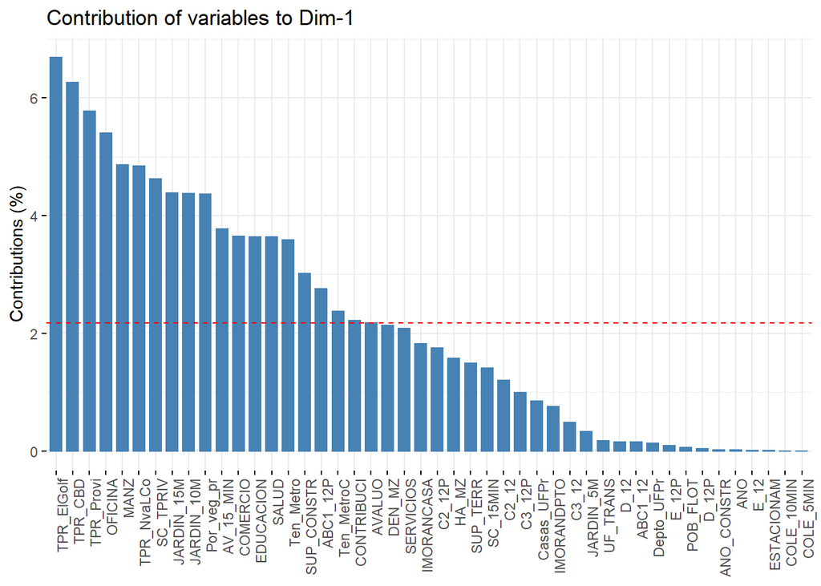

```r
#A continuación vemos que variables son las que más peso/información tienen en cada componente
var = get_pca_var(pca)
a = fviz_contrib(pca, "var", axes=1, xtickslab.rt=90)
plot(a,main = "Contribución en el porcentaje de varianza para la primea componente")
```

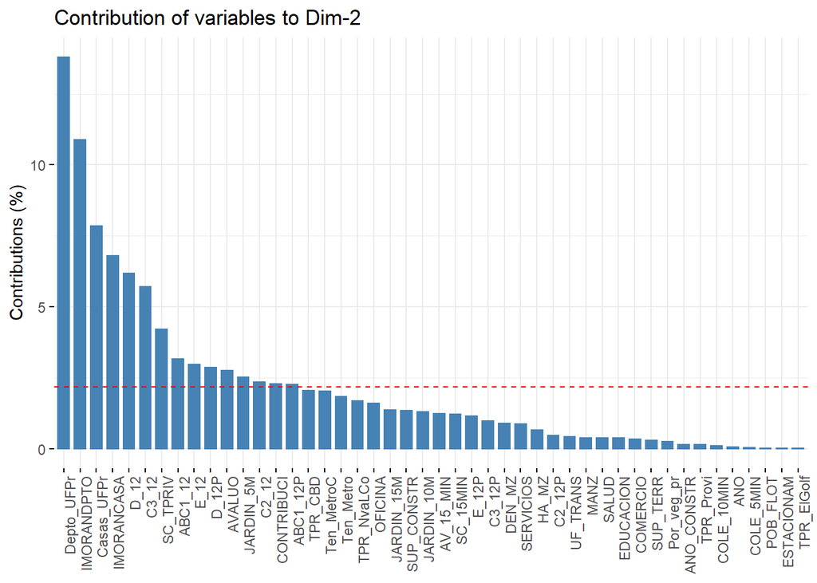

```r
a = fviz_contrib(pca, "var", axes=2, xtickslab.rt=90)
plot(a,main = "Contribución en el porcentaje de varianza para la segunda componente")
```

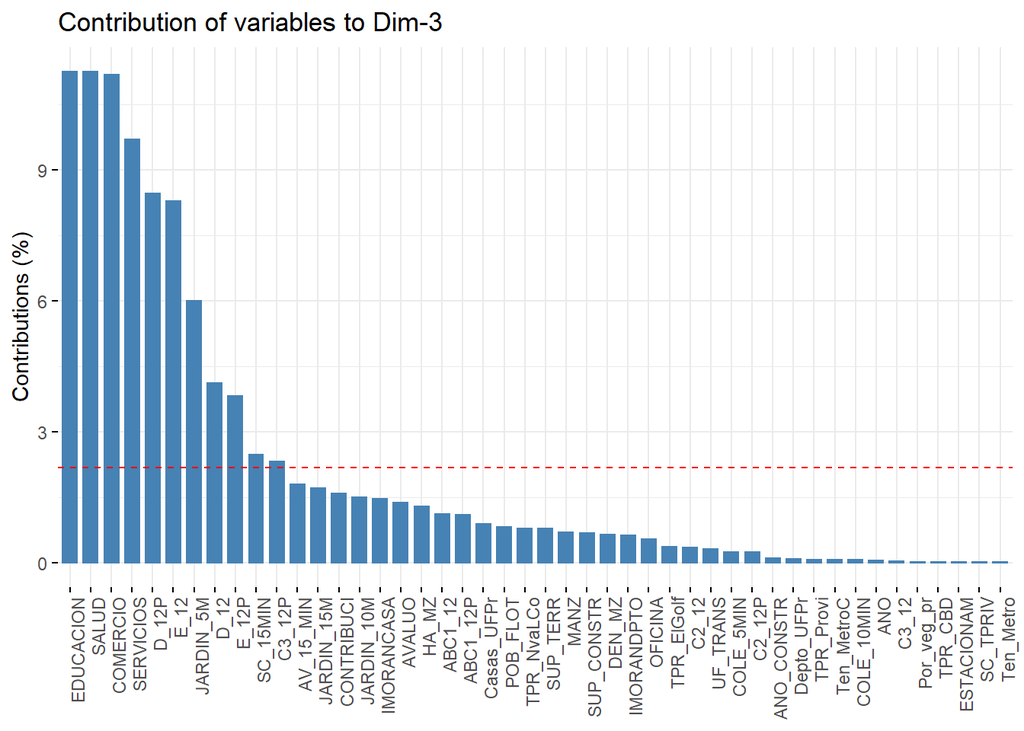

```r
a = fviz_contrib(pca, "var", axes=3, xtickslab.rt=90)
plot(a,main = "Contribución en el porcentaje de varianza para la tercera componente")
```

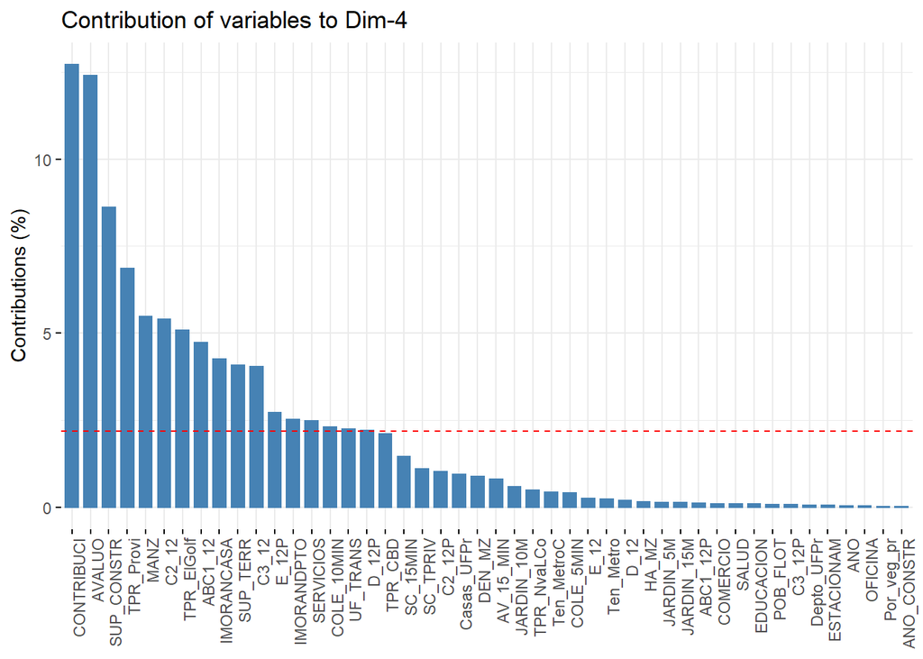

```r
a = fviz_contrib(pca, "var", axes=4, xtickslab.rt=90)
plot(a,main = "Contribución en el porcentaje de varianza para la cuarta componente")
```

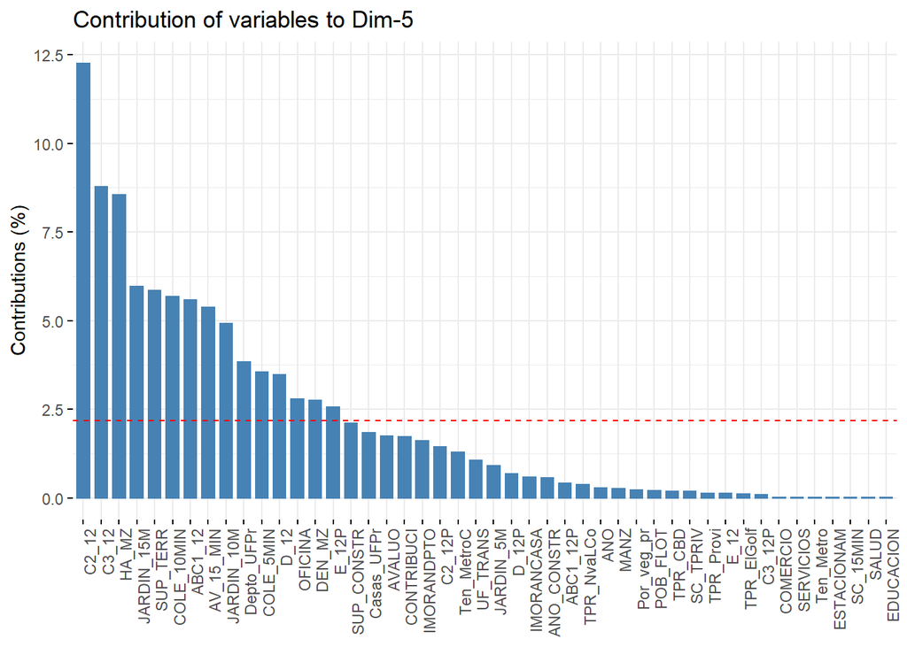

```r
a = fviz_contrib(pca, "var", axes=5, xtickslab.rt=90)
plot(a,main = "Contribución en el porcentaje de varianza para la quinta componente")
```

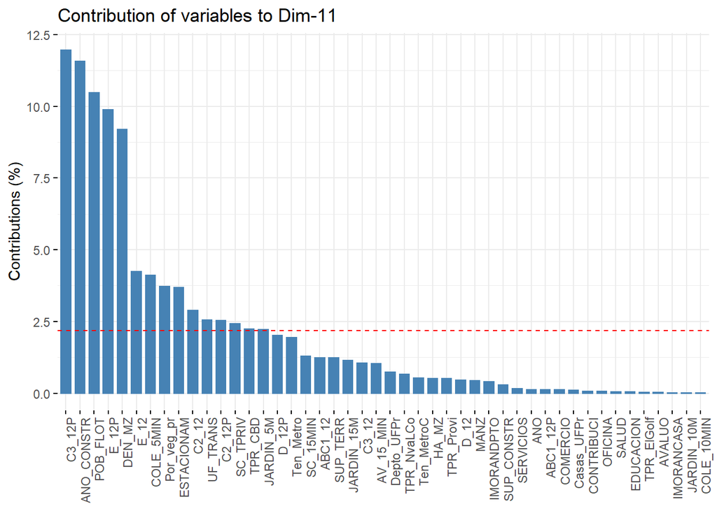

```r
a = fviz_contrib(pca, "var", axes=11, xtickslab.rt=90)
plot(a,main = "Contribución en el porcentaje de varianza para la onceava componente")
```

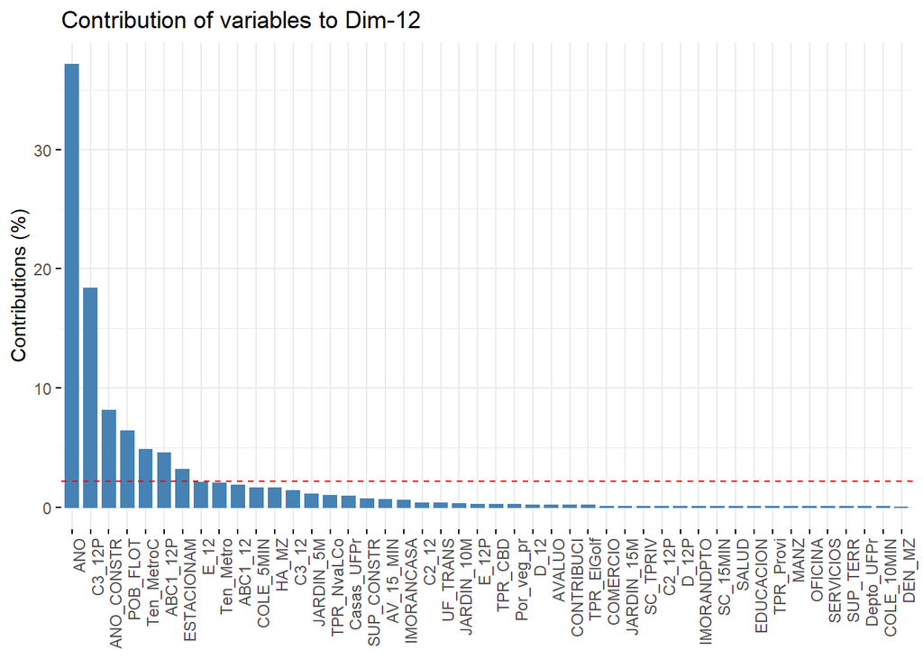

```r
a = fviz_contrib(pca, "var", axes=12, xtickslab.rt=90)
plot(a,main = "Contribución en el porcentaje de varianza para la doceava componente")
```

Para la primera componente del PCA, vemos que las variables que más información aportan son aquellas que indican el tiempo de transporte hacia lugares como el Golf, Providencia, etc.

Para la tercera componente encontramos que las variables relacionadas a los servicios son las que más destacan, como SALUD, EDUCACIÓN, COMERCIO, SERVICIO, etc.

Para la cuarta componente notamos que variables como CONTRIBUCION y AVALUO, son las que más impacto tienen.

Por otro lado, si analizamos las componentes 11 y 12, vemos que recién ahí aparecen los años, ANO y ANO_CONSTR, lo que nos hace confirmar que esas variables no aportan mucha información.

# Modelamiento

Modelamiento del problema:

```
A continuación en base a los resultados obtenidos del procedimiento anterior de limpieza y procesamiento de datos, se procedió a realizar nuevamente un PCA el cual tiene como finalidad poder determinar las variables que mejor describen el comportamiento general de los datos entre estos 13 componentes de mayor peso.
```

Posteriormente de haber realizado el PCA se realizó el clustering. Para este trabajo se escogió utilizar el método K means. Este es un método de agrupamiento, que tiene como objetivo la partición de un conjunto de n observaciones en k grupos en el que cada observación pertenece al grupo cuyo valor medio es más cercano. Esta agrupación se basa en sus distintas características, minimizando la suma de distancias entre cada objeto y el centroide de su grupo o cluster. Antes de realizar el K means, lo primero que se debe determinar es el número de cluster. para esto nosotros utilizamos el método de silhouette. Esto indica que tan similar es un objeto a su propio “cúmulo” en comparación con los otros cúmulos. mientras mayor sea el valor de la silueta mejor emparejado está con su propio cúmulo y mal emparejado con sus vecinos, por lo que, si la mayoría de los objetos tiene un valor alto, se puede decir que la configuración del cúmulo es apropiada, si muchos valores son bajos o negativos, se puede concluir que la cantidad de cúmulos es mucha o muy poca. De esta forma se logró asignar la cantidad de clusters que debería tener el K Means, obteniendo una cantidad de 6 clusters.

### PCA con las variables seleccionadas

```r
#--------------Hacemos otro PCA pero con las componentes seleccionadas------------------
#Como encontramos que 13 componentes cumplian con el eigenvalue >= 1, haremos un nuevo pca con 13 componentes
pca1 = prcomp(datos_sin_na, scale.=TRUE, rank. = 13)

summary(pca1)
```

```
## Importance of first k=13 (out of 46) components:
##                           PC1    PC2     PC3     PC4     PC5     PC6     PC7
## Standard deviation     3.2776 2.2520 1.75653 1.67112 1.47472 1.38275 1.33192
## Proportion of Variance 0.2335 0.1103 0.06707 0.06071 0.04728 0.04157 0.03857
## Cumulative Proportion  0.2335 0.3438 0.41086 0.47157 0.51885 0.56042 0.59898
##                            PC8     PC9    PC10    PC11    PC12   PC13
## Standard deviation     1.24024 1.18026 1.05826 1.05247 1.02126 1.0013
## Proportion of Variance 0.03344 0.03028 0.02435 0.02408 0.02267 0.0218
## Cumulative Proportion  0.63242 0.66271 0.68705 0.71113 0.73380 0.7556
```

```r
resultados <- pca1$x
str(resultados)
```

```
##  num [1:21079, 1:13] 0.2026 0.2164 0.1372 0.0601 0.6236 ...
##  - attr(*, "dimnames")=List of 2
##   ..$ : NULL
##   ..$ : chr [1:13] "PC1" "PC2" "PC3" "PC4" ...
```

### Kmeans

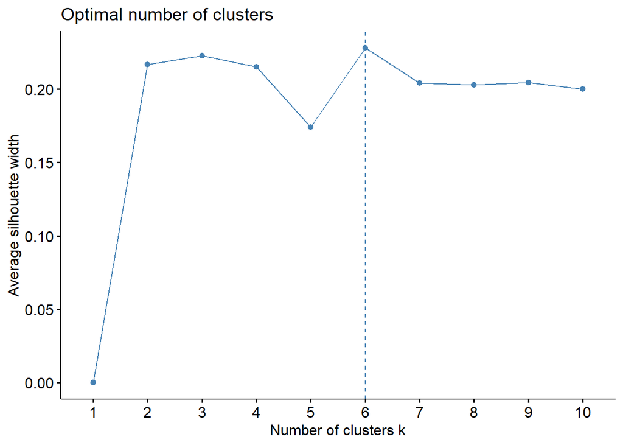

```r
#Hacemos un Kmeans con los resultados del PCA
fviz_nbclust(resultados, kmeans, method = c("silhouette")) #Encontramos el número optimo de clusters (6)
```

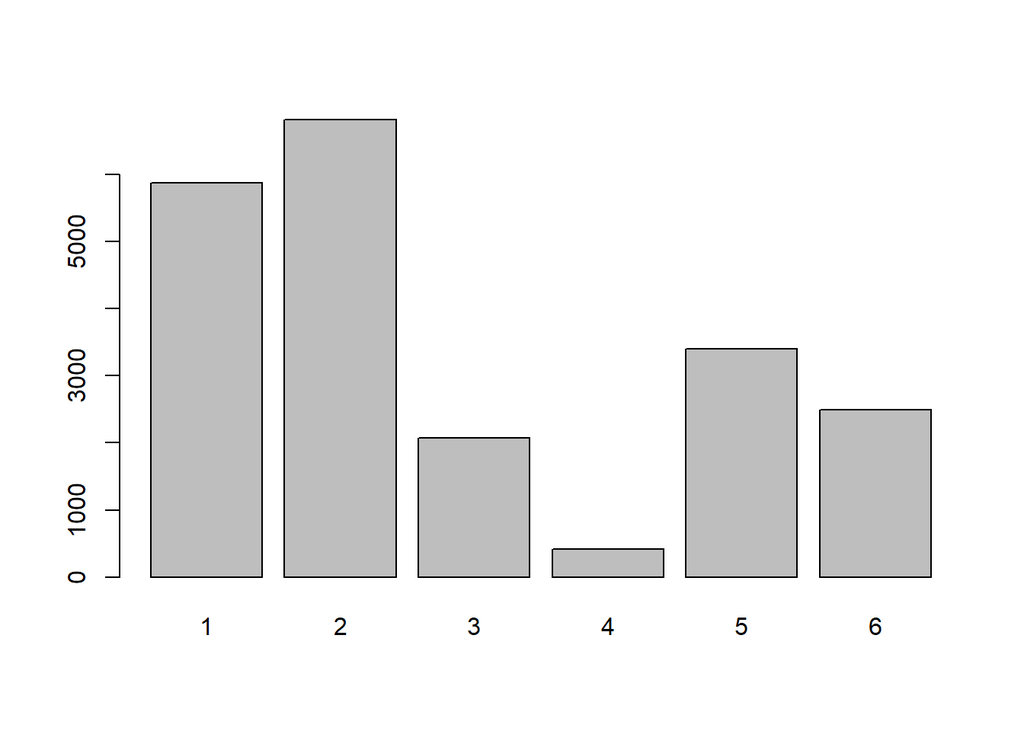

```r
kmeans_optimo = kmeans(resultados,centers = 6)
#kmeans_optimo

geom_sin_na$cluster_kmeans = as.factor(kmeans_optimo$cluster) #agregamos a los datos la columna que asigna cada fila a un cluster
plot(geom_sin_na$cluster_kmeans) #frecuencia de cada cluster
```

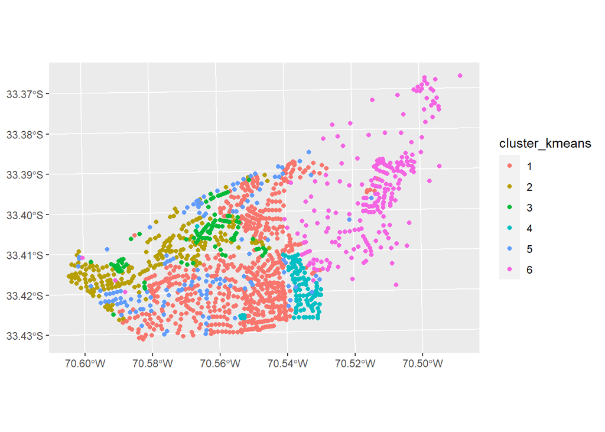

```r
geom_k = geom_sin_na %>% dplyr::select(cluster_kmeans,geometry)
ggplot(geom_sin_na) +
  geom_sf(aes(color = cluster_kmeans))
```

```r
datos_sin_na$cluster_kmeans = as.factor(kmeans_optimo$cluster) #agregamos a los datos la columna que asigna cada fila a un cluster
```

# Análisis de datos

Análisis de resultados: De las variables que se retuvieron tras considerar los 13 componentes del PCA, y observando el cluster obtenido del K means, uno puede observar que se produjeron 6 clusters distintos, siendo el cluster más grande el número 2 con 6817 puntos y el cluster más pequeño fue el número 4 con 415 puntos respectivamente. Observando las diferentes variables dentro de cada cluster, podemos obtener datos que diferencian a los clusters entre sí, estos pueden ser la distancia a los diferentes subcentros, el número de habitantes, la educación, el comercio, entre muchas otras.

```r
#------------------ESTA SECCIÓN ARROJA LAS TABLAS DE CADA CLUSTER-----------
#------------------DECOMENTAR EN CASO DE COMPROBAR LA INFORMACIÓN-----------
#primer_cluster = datos_sin_na %>% dplyr::filter(cluster_kmeans == 1)
#summary(primer_cluster)

#segundo_cluster = datos_sin_na %>% dplyr::filter(cluster_kmeans == 2)
#summary(segundo_cluster)

#tercer_cluster = datos_sin_na %>% dplyr::filter(cluster_kmeans == 3)
#summary(tercer_cluster)

#cuarto_cluster = datos_sin_na %>% dplyr::filter(cluster_kmeans == 4)
#summary(cuarto_cluster)

#quinto_cluster = datos_sin_na %>% dplyr::filter(cluster_kmeans == 5)
#summary(quinto_cluster)

#sexto_cluster = datos_sin_na %>% dplyr::filter(cluster_kmeans == 6)
#summary(sexto_cluster)
```

El cluster 1 corresponde a casas de un ingreso medio-alto, estas viviendas solamente se encuentran cerca de oficinas de trabajo, es decir que todos los otros puntos como educación, salud, entre otros, están más bien alejados de este cluster, por lo que pueden corresponder a grupos de adultos jóvenes trabajadores.

El cluster 2 podría corresponder a departamentos debido a la superficie de m2 y cantidad de estacionamientos de la que disponen, también son viviendas muy cercanas a medios de transporte, por lo que este cluster se caracteriza por personas de un ingreso medio que buscan tener un fácil acceso a medios de transporte.

El cluster 3 corresponde a viviendas que apuntan a la misma utilidad que el cluster 2, con diferencia de que corresponden a viviendas más nuevas y también de una superficie mayor, además las personas que están en estas viviendas tienen un nivel socioeconómico medio-alto, mayor a las personas del cluster 2.

El cluster 5 corresponde a casas de un ingreso medio-alto con el mayor porcentaje de cercanía a colegios y jardines, además de también estar cerca de centros de salud, pero lejos de servicios, este cluster puede corresponder a grupos de familia que buscan tener fuentes de educación cercanas para sus hijos.

El cluster 6 corresponde a viviendas de alto recursos. Con viviendas grandes y patios grandes. El 82% del cluster son abc1, es decir, clase alta y media lata. En esta agrupación se ve que hay pocos estacionamientos, esto nos indica que no hay mucha construcción de edificios, lo cual tiene sentido, debido a que es el cluster un una menor densidad por manzana. Este grupo de viviendas se encuentra alejada del transporte público y comercios. Son el cluster con los precios más elevados.

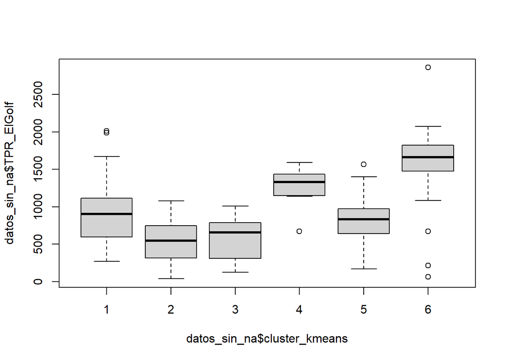

```r
#-----------Visualizamos los clusters----------------------
#Hacemos un boxplot de las variables que más peso tenian en cada componente de los 5 primeros PCA, para compararlos por cluster
boxplot(datos_sin_na$TPR_ElGolf ~ datos_sin_na$cluster_kmeans)
```

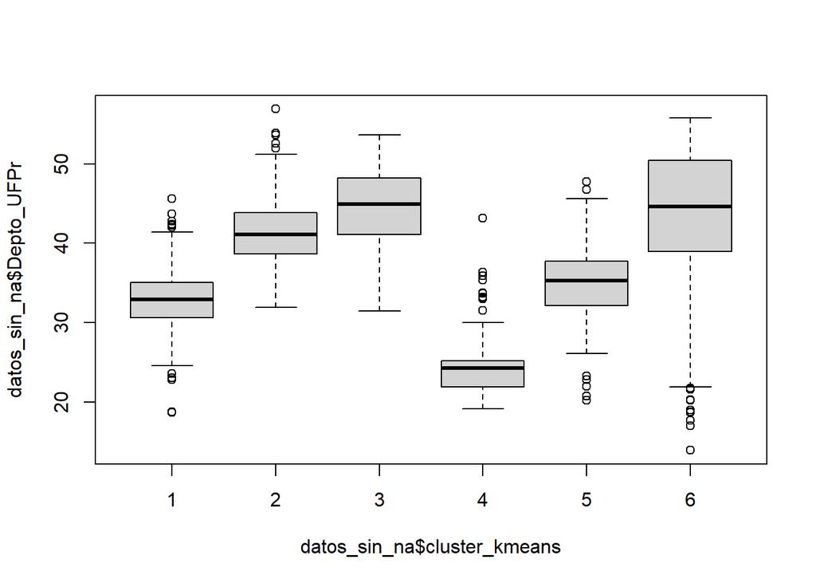

```r
boxplot(datos_sin_na$Depto_UFPr ~ datos_sin_na$cluster_kmeans)
```

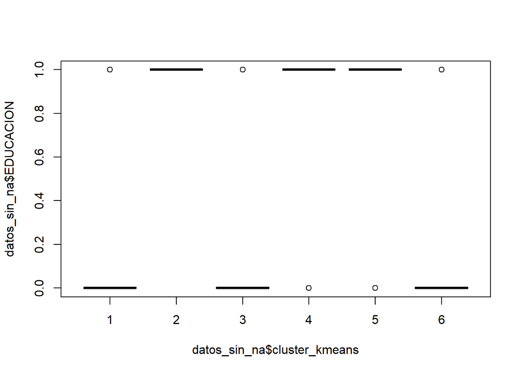

```r
boxplot(datos_sin_na$EDUCACION ~ datos_sin_na$cluster_kmeans)
```

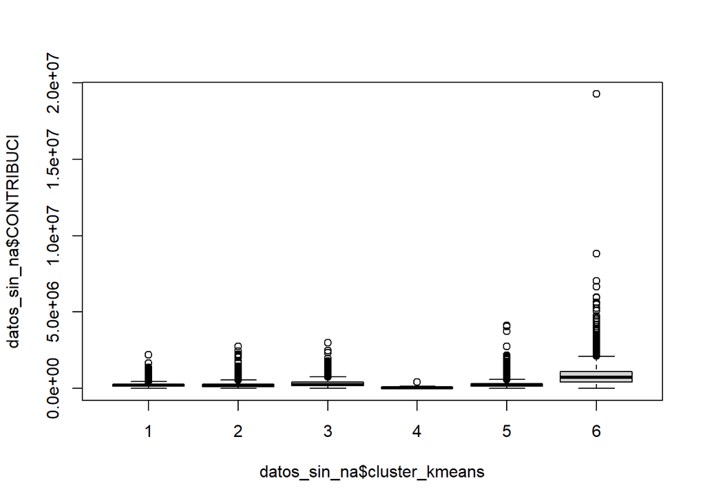

```r
boxplot(datos_sin_na$CONTRIBUCI ~ datos_sin_na$cluster_kmeans)
```

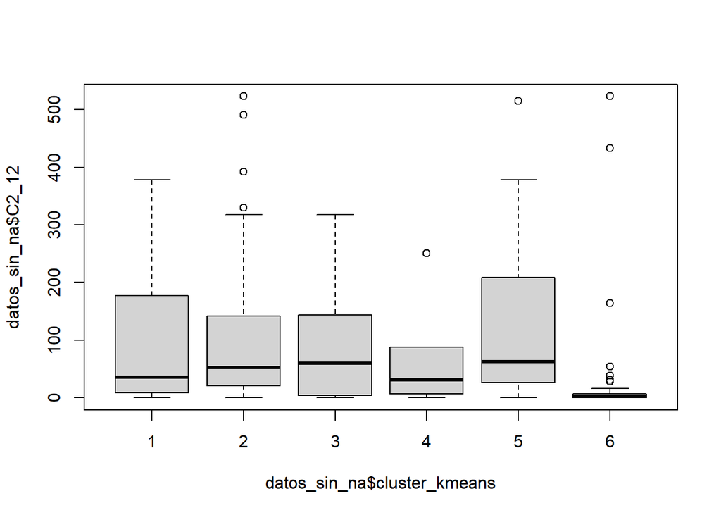

```r
boxplot(datos_sin_na$C2_12 ~ datos_sin_na$cluster_kmeans)
```

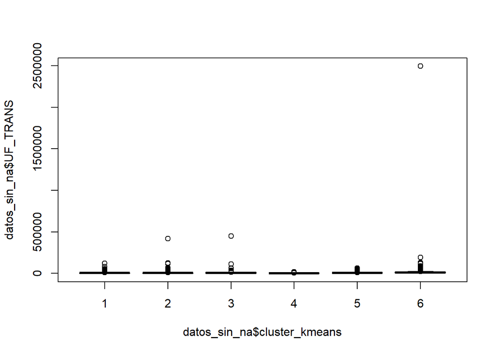

```r
#Viendo el boxplot de las UF nos damos cuenta que hay valores que se escapan mucho de los bigotes del box plot, por lo que
# filtraremos hasta un precio máximo de 10.000 uf
boxplot(datos_sin_na$UF_TRANS ~ datos_sin_na$cluster_kmeans)
```

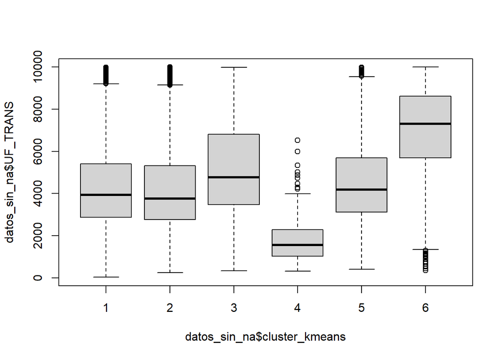

```r
datos_sin_na = datos_sin_na %>% dplyr::filter(UF_TRANS < 10000 )
geom_sin_na = geom_sin_na %>% dplyr::filter(UF_TRANS < 10000 )
boxplot(datos_sin_na$UF_TRANS ~ datos_sin_na$cluster_kmeans)
```

```
## No summary function supplied, defaulting to `mean_se()`
```

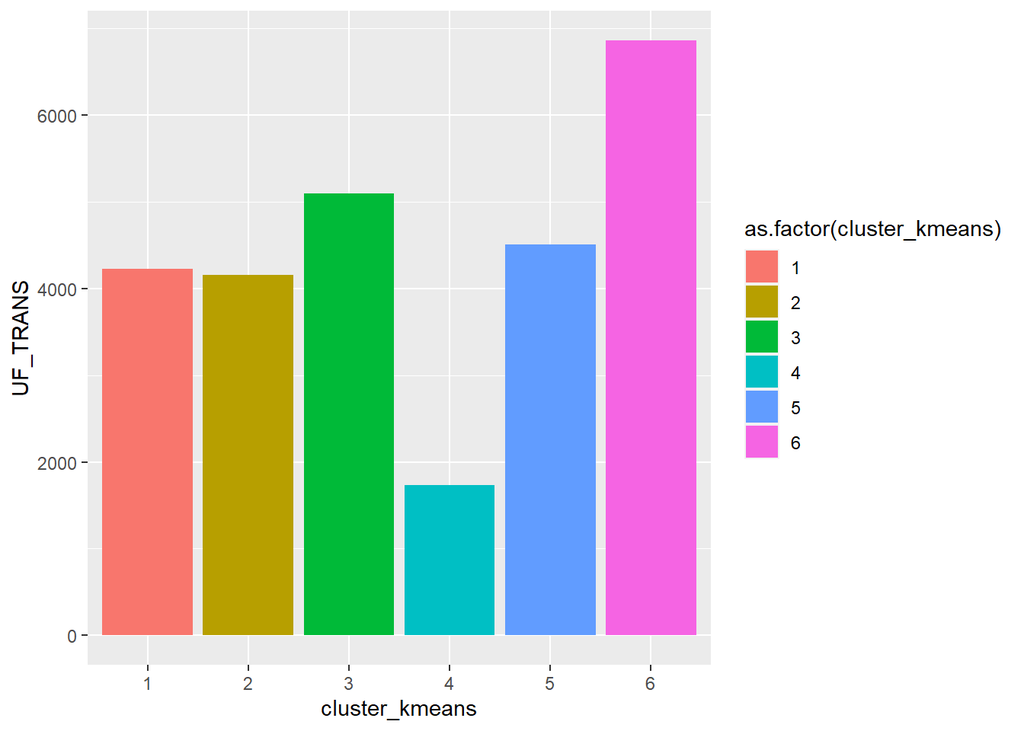

```r
#Graficamos la media de UF por cada cluster
ggplot(geom_sin_na) +
  geom_bar(aes(cluster_kmeans, UF_TRANS, fill = as.factor(cluster_kmeans)),
           position = "dodge", stat = "summary", fun.y = "mean")
```

Conclusión:

De esto podemos afirmar que se observaron 6 grupos con notorias diferencias y características respecto a su ubicación, densidad poblacional, estrato económico, viviendas y precios. Siendo el cluster 6 el que tiene precios más elevados en sus viviendas, mientras que el cluster 4 es el que tiene menores precios.

Referencias:

https://rpubs.com/Bury/ClusteringOnPcaResults